# Frequentist Fixed-effects Meta Regression

- Show All Code
- Hide All Code
- View Source

Author

Ananda Biswas

Published

October 29, 2026

## Required Libraries

**Show/Hide Code**

```r
library(openxlsx)

library(gt)
library(tidyverse)

library(metafor)
```

## Loading Data

**Show/Hide Code**

```r
df1 <- read.xlsx(data.path, sheet = 1)
```

## Initial Sanity Checks

**Show/Hide Code**

```r
str(df1)
```

```
'data.frame':   18 obs. of  10 variables:
 $ Study           : chr  "Czuczman, 2017" "Aribi, 2010" "Pettengell, 2020" "Shi, 2020" ...
 $ Sample.n1       : num  51 48 155 22 70 40 222 180 112 42 ...
 $ Sample.n2       : num  51 48 157 20 70 40 223 179 118 39 ...
 $ Follow-up.months: num  NA 13 NA 45 18 48.9 10.9 47.2 15.5 10 ...
 $ HR.OS           : num  0.91 0.45 1.13 0.228 0.79 0.42 0.9 0.73 0.63 1.17 ...
 $ OS.ln.HR        : num  -0.041 -0.3565 0.0531 -0.6421 -0.1024 ...
 $ OS.se           : num  0.209 0.112 0.179 0.252 0.166 ...
 $ HR.PFS          : num  0.64 0.44 0.85 0.398 0.6 0.39 1.12 0.51 0.53 1.29 ...
 $ PFS.ln.HR       : num  -0.1938 -0.3565 -0.0706 -0.4001 -0.2218 ...
 $ PFS.se          : num  0.148 0.107 0.128 0.206 0.112 ...
```

**Show/Hide Code**

```r
dim(df1)
```

```
[1] 18 10
```

RR-DLBCL Data

| Study | Sample.n1 | Sample.n2 | Follow-up.months | HR.OS | OS.ln.HR | OS.se | HR.PFS | PFS.ln.HR | PFS.se |
| --- | --- | --- | --- | --- | --- | --- | --- | --- | --- |
| Czuczman, 2017 | 51.0000 | 51.0000 | NA | 0.9100 | −0.0410 | 0.2092 | 0.6400 | −0.1938 | 0.1480 |
| Aribi, 2010 | 48.0000 | 48.0000 | 13.0000 | 0.4500 | −0.3565 | 0.1122 | 0.4400 | −0.3565 | 0.1071 |
| Pettengell, 2020 | 155.0000 | 157.0000 | NA | 1.1300 | 0.0531 | 0.1786 | 0.8500 | −0.0706 | 0.1276 |
| Shi, 2020 | 22.0000 | 20.0000 | 45.0000 | 0.2280 | −0.6421 | 0.2518 | 0.3980 | −0.4001 | 0.2061 |
| Pettengell, 2012 | 70.0000 | 70.0000 | 18.0000 | 0.7900 | −0.1024 | 0.1658 | 0.6000 | −0.2218 | 0.1122 |
| Sehn, 2022 | 40.0000 | 40.0000 | 48.9000 | 0.4200 | −0.3768 | 0.1224 | 0.3900 | −0.4089 | 0.1097 |
| Van Imhoff, 2017 | 222.0000 | 223.0000 | 10.9000 | 0.9000 | −0.0458 | 0.1148 | 1.1200 | 0.0492 | 0.1352 |
| Westin, 2023 | 180.0000 | 179.0000 | 47.2000 | 0.7300 | −0.1367 | 0.1122 | 0.5100 | −0.2924 | 0.0740 |
| Bartlett, 2025 | 112.0000 | 118.0000 | 15.5000 | 0.6300 | −0.2007 | 0.1122 | 0.5300 | −0.2757 | 0.0893 |
| Morschhauser, 2019 | 42.0000 | 39.0000 | 10.0000 | 1.1700 | 0.0682 | 0.3673 | 1.2900 | 0.1106 | 0.3520 |
| Abramson, 2024 | 183.0000 | 91.0000 | 20.7000 | 0.6200 | −0.2076 | 0.1148 | 0.4000 | −0.3979 | 0.0740 |
| Vose, 2013 | 111.0000 | 113.0000 | 25.5000 | 1.1400 | 0.0569 | 0.2679 | 1.0800 | 0.0334 | 0.1990 |
| Ramchandren, 2023 | 55.0000 | 34.0000 | NA | 0.8300 | −0.0809 | 0.2423 | 0.8800 | −0.0555 | 0.2590 |
| Gisselbrecht, 2010 | 202.0000 | 194.0000 | 27.0000 | 1.2800 | 0.1072 | 0.1760 | 1.0700 | 0.0294 | 0.1352 |
| Kamdar, 2025 | 92.0000 | 92.0000 | 33.9000 | 0.7570 | −0.1209 | 0.1811 | 0.4220 | −0.3747 | 0.0918 |
| Kong, 2023 | 35.0000 | 21.0000 | 12.0000 | 0.7900 | −0.1024 | 0.3342 | 0.6400 | −0.1938 | 0.3061 |
| Zhang, 2024 | 28.0000 | 14.0000 | 7.5000 | 0.5500 | −0.2596 | 0.2934 | 0.5000 | −0.3010 | 0.2066 |
| Ying, 2023 | 27.0000 | 31.0000 | 17.9000 | 0.6600 | −0.1805 | 0.3900 | 0.7100 | −0.1487 | 0.2679 |

## Derived Quantities

**Show/Hide Code**

```r
df1$weight <- 1 / (df1$OS.se)^2
```

## Generating Treatment Effect on Surrogate Endpoint in New Trials

**Show/Hide Code**

```r
range(df1$HR.PFS)
```

```
[1] 0.39 1.29
```

**Show/Hide Code**

```r
# Suppose 1000 new trials reporting TE on surrogate endpoint only
new.data <- data.frame(PFS.ln.HR = log(seq(0.38, 1.3, length=1000)))
```

## Model

Meta-regression is an extension of meta-analysis that includes the surrogate endpoint as a study-level covariate. The model is written as

$$\widehat{\theta}_i
=
\theta+\beta\widehat{\alpha}_i+\varepsilon_i,
\qquad
i=1,\ldots,N,$$

where

$$\varepsilon_i
\overset{\mathrm{iid}}{\sim}
N(0,\sigma^2).$$
Here:

- $\widehat{\theta}_i$ = estimated treatment effect on the final endpoint in study $i$;
- $\widehat{\alpha}_i$ = estimated treatment effect on the surrogate endpoint in study $i$;
- $\theta$ = intercept;
- $\beta$ = regression coefficient describing the association between surrogate and final treatment effects.

Here we assume that $\theta$ is common for all studies and the only reason observed treatment effect $\widehat{\theta_i}$’s are different from $\theta$ is the sampling error (in addition to the observed treatment effect on surrogate endpoint of that study).

## Model Fitting

**Show/Hide Code**

```r
fit.FEMR <- metafor::rma(OS.ln.HR ~ 1 + PFS.ln.HR, sei = OS.se, data = df1, method = "FE")
summary(fit.FEMR)
```

```
Fixed-Effects with Moderators Model (k = 18)

  logLik  deviance       AIC       BIC      AICc
 10.1990    6.3197  -16.3979  -14.6172  -15.5979

I^2 (residual heterogeneity / unaccounted variability): 0.00%
H^2 (unaccounted variability / sampling variability):   0.39
R^2 (amount of heterogeneity accounted for):            59.64%

Test for Residual Heterogeneity:
QE(df = 16) = 6.3197, p-val = 0.9843

Test of Moderators (coefficient 2):
QM(df = 1) = 10.3189, p-val = 0.0013

Model Results:

           estimate      se    zval    pval    ci.lb   ci.ub
intrcpt      0.0073  0.0672  0.1087  0.9134  -0.1244  0.1390
PFS.ln.HR    0.7479  0.2328  3.2123  0.0013   0.2916  1.2042  **

---
Signif. codes:  0 '***' 0.001 '**' 0.01 '*' 0.05 '.' 0.1 ' ' 1
```

## Prediction of TE on Clinical Outcome in New Trials and Confidence Intervals

We assume that there is no between-trial heterogeneity in either the target or the surrogate endpoint (fixed-effects assumption). So confidence intervals can be interpreted as prediction intervals.

**Show/Hide Code**

```r
FEMR.ci <- data.frame(predict(fit.FEMR, new.data$PFS.ln.HR))
head(FEMR.ci) |>
  gt()
```

| pred | se | ci.lb | ci.ub |
| --- | --- | --- | --- |
| -0.7163390 | 0.1740720 | -1.057514 | -0.3751640 |
| -0.7145287 | 0.1735221 | -1.054626 | -0.3744315 |
| -0.7127227 | 0.1729737 | -1.051745 | -0.3737006 |
| -0.7109212 | 0.1724266 | -1.048871 | -0.3729712 |
| -0.7091239 | 0.1718809 | -1.046004 | -0.3722435 |
| -0.7073310 | 0.1713367 | -1.043145 | -0.3715172 |

**Show/Hide Code**

```r
FEMR.ci$HR.OS <- exp(FEMR.ci$pred)
FEMR.ci$HR.PFS <- exp(new.data$PFS.ln.HR)

head(FEMR.ci) |>
  gt()
```

| pred | se | ci.lb | ci.ub | HR.OS | HR.PFS |
| --- | --- | --- | --- | --- | --- |
| -0.7163390 | 0.1740720 | -1.057514 | -0.3751640 | 0.4885375 | 0.3800000 |
| -0.7145287 | 0.1735221 | -1.054626 | -0.3744315 | 0.4894227 | 0.3809209 |
| -0.7127227 | 0.1729737 | -1.051745 | -0.3737006 | 0.4903074 | 0.3818418 |
| -0.7109212 | 0.1724266 | -1.048871 | -0.3729712 | 0.4911915 | 0.3827628 |
| -0.7091239 | 0.1718809 | -1.046004 | -0.3722435 | 0.4920751 | 0.3836837 |
| -0.7073310 | 0.1713367 | -1.043145 | -0.3715172 | 0.4929582 | 0.3846046 |

## Trial-level Association Plot

**Show/Hide Code**

```r
FEMR.association.plot <- ggplot(df1, aes(x = HR.PFS, y = HR.OS)) +
  geom_ribbon(aes(x = HR.PFS, ymin = exp(ci.lb), ymax = exp(ci.ub)), data = FEMR.ci, fill = "#D2D808", alpha = 0.4) +
  geom_smooth(aes(x = HR.PFS, y = HR.OS), data = FEMR.ci, stat = 'identity', col = "#999E0E") +
  geom_point(aes(size = weight), shape = 21, col = "#454545", fill = "#9E235E") +
  scale_x_continuous(transform = "log",
                     limits = c(0.38, 1.3),
                     breaks=c(0.1,0.2,0.3,0.4,0.5,0.7,1,1.2),
                     expand = c(0.01, 0.01)) +
  scale_y_continuous(transform = "log",
                     limits = c(0.2, 2.0),
                     breaks=c(0.2,0.3,0.4,0.5,0.7,1,1.2,1.5,2),
                     expand = c(0.01, 0.01)) +
  geom_hline(yintercept = 1, linetype = 'dashed') +
  xlab("Progression-free survival hazard ratio (log scale)")+
  ylab(paste("Overall survival hazard ratio" , "\n", "\U00B1", "95% confidence and prediction intervals (log scale)")) +
  ggtitle("Frequentist Fixed-effects Meta-regression") +
  theme_bw() +
  scale_colour_hue("trial") +
  theme(legend.position = "none",
        axis.title.x = element_text(size = 14, color = "#6A1A41", face = "bold"),
        axis.title.y = element_text(size = 14, color = "#6A1A41", face = "bold"),
        plot.title = element_text(size = 15, face = "bold"))
```

**Show/Hide Code**

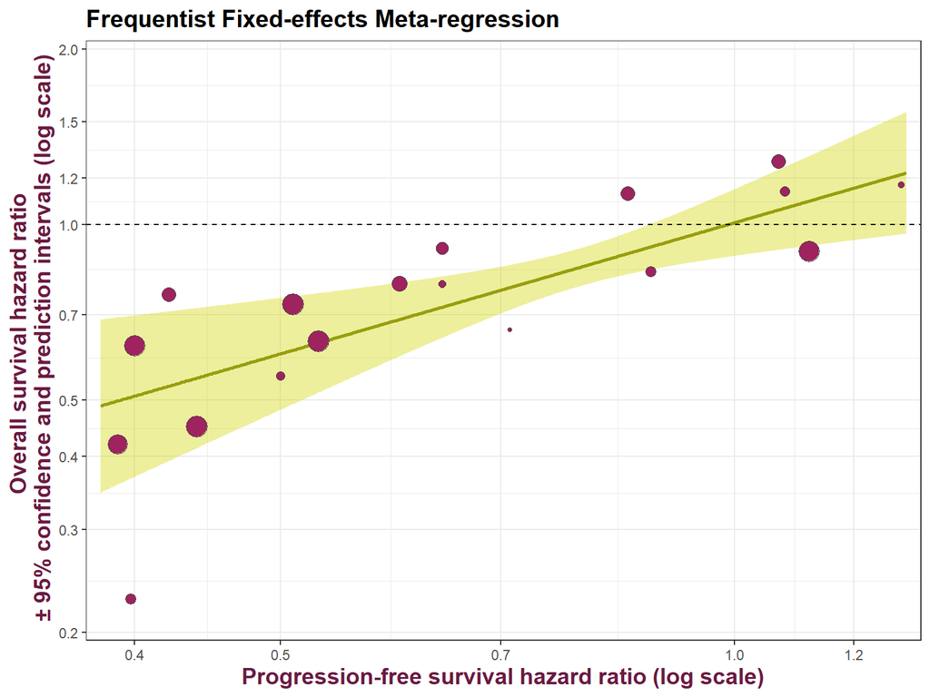

```r
FEMR.association.plot
```

## Surrogate Threshold Effect

**Show/Hide Code**

```r
candidate.HR.PFS <- FEMR.ci %>%
  filter(ci.ub < 0) %>%
  pull(HR.PFS)

FEMR.STE <- max(candidate.HR.PFS)

FEMR.STE |> round(3)
```

```
[1] 0.878
```

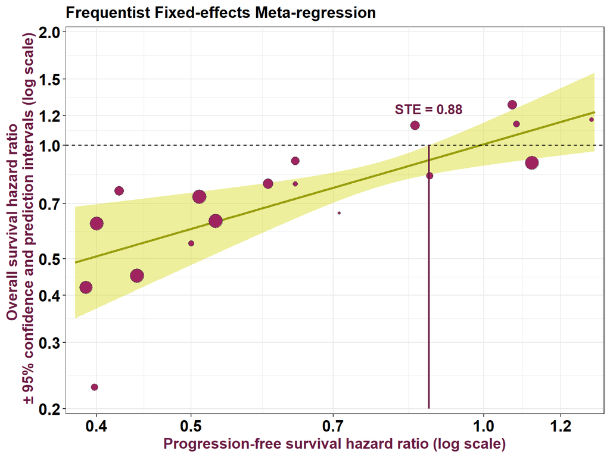